# Общее описание рациона

## Динамика пустых желудков

Модель, котрую строим имеет следующий вид

Empty ~ s(Year) + s(DOY) + s(L), data = total_weight, family = “binomial”

Вот результаты подбора модели

```
##
## Family: binomial
## Link function: logit
##
## Formula:
## Empty ~ s(Year) + s(DOY) + s(L)
##
## Parametric coefficients:
##             Estimate Std. Error z value Pr(>|z|)
## (Intercept) -1.16228    0.05433  -21.39   <2e-16 ***
## ---
## Signif. codes:  0 '***' 0.001 '**' 0.01 '*' 0.05 '.' 0.1 ' ' 1
##
## Approximate significance of smooth terms:
##           edf Ref.df Chi.sq  p-value
## s(Year) 7.761  8.571 41.276 1.81e-06 ***
## s(DOY)  6.864  7.913 65.044  < 2e-16 ***
## s(L)    1.951  2.487  2.178    0.493
## ---
## Signif. codes:  0 '***' 0.001 '**' 0.01 '*' 0.05 '.' 0.1 ' ' 1
##
## R-sq.(adj) =  0.0498   Deviance explained = 5.16%
## UBRE = 0.084895  Scale est. = 1         n = 2013
```

Статистически значимыми была как многолетняя динамика, так и сезонные изменения, но связи с размерами не выявлется.

Вот визуализация модели

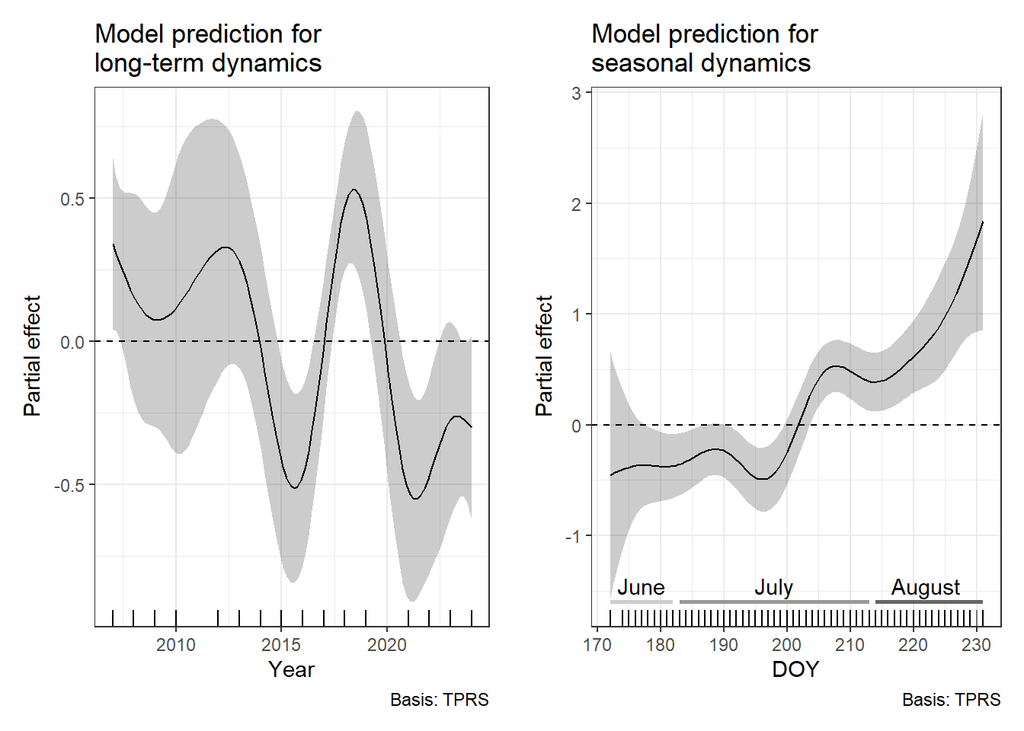

На этих рисунках, как и везде, горизонтальная пунктирная линия отражает среднее по популяции значение. Ниже нуля - меньше среднего и наоборот.

С сезонной динамикой все более или менее понятно. К концу лета голодных становится больше. Биология мне непонятна: все съели? Нерест? Уже нагуляли жир и больше не надо? Пищевые объекты мигрировали? И т.д.

С многолетней динамикой сложнее. С динамикой размеров это, скорее всего, не связано, так как нет связи частоты пустых с размером, который был включен в модель. То есть было два нажористых периода, когда частота пустых была ниже среднего.

## Динамика веса пищевого комка в заполненных желудках

Анализируем общий вес пищи в желудках

Модель, котрую строим имеет следующий вид

Total_Weight ~ s(Year) + s(DOY) + s(L)

Вот результаты подбора модели

```
##
## Family: gaussian
## Link function: identity
##
## Formula:
## Total_Weight ~ s(Year) + s(DOY) + s(L, k = 5)
##
## Parametric coefficients:
##             Estimate Std. Error t value Pr(>|t|)
## (Intercept)   8.5773     0.2249   38.14   <2e-16 ***
## ---
## Signif. codes:  0 '***' 0.001 '**' 0.01 '*' 0.05 '.' 0.1 ' ' 1
##
## Approximate significance of smooth terms:
##           edf Ref.df      F  p-value
## s(Year) 6.630  7.694  5.141 3.84e-06 ***
## s(DOY)  1.631  2.042  0.938    0.387
## s(L)    3.816  3.979 40.743  < 2e-16 ***
## ---
## Signif. codes:  0 '***' 0.001 '**' 0.01 '*' 0.05 '.' 0.1 ' ' 1
##
## R-sq.(adj) =  0.117   Deviance explained = 12.4%
## GCV = 76.975  Scale est. = 76.308    n = 1509
```

Выявляется многолетняя динамика и, естественно, связь с размером. Сезонной динамики не выявляется.

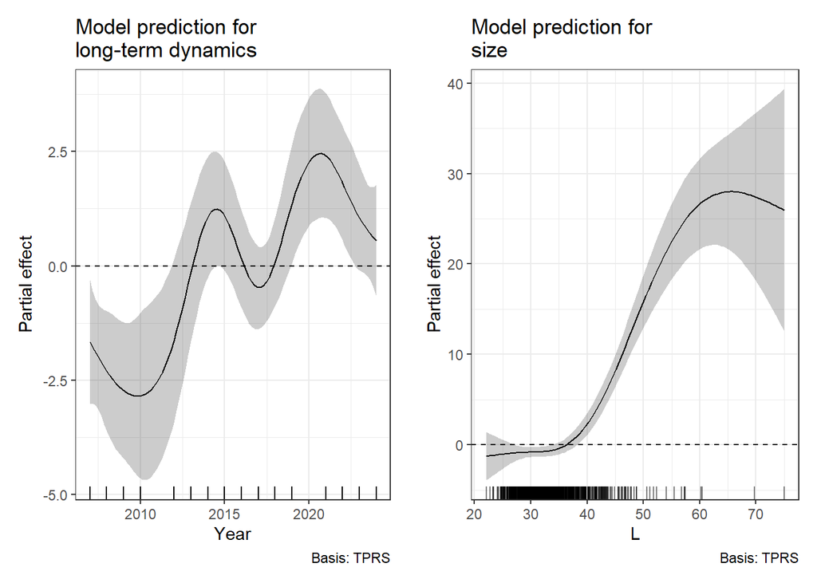

В принципе, хорошо видно, что общее количество еды в желудках было максимальным, в те годы, когда была минимальная доля пустых. Так что, скорее всего, это про голодные и сытые годы. При этом видно, что после где-то 2015 года кормовая база стала сильно лучше. Ну а связь с размером очевидна.

## Состав пищевого комка

## Динамика встречаемости пищевых объектов

Ранжируем виды по их встречаемости (за все годы исследования)

За порог отсечения принимаем встречаемость более 5%. Тогда в число наиболее частых пищевых объектов попадают следующие виды корма:

```
## [1] "G.aculeatus"          "Nereis_sp."           "Fish_eggs"
## [4] "C.pallasii_marisalbi" "O.aculeata"
```

Для этих видов будем строить модель многолетней и сезонной динамики встречаемости.

Модель имеет следующий вид

Presence ~ s(Year, by = Species) + s(DOY, by = Species) + s(L, by = Species, k =5) + Species

То есть мы сразу очениваем и многолетнюю динамику, и сезонную динамику и связь с размерами.

Вот результаты этой модели

```
##
## Family: binomial
## Link function: logit
##
## Formula:
## Presence ~ s(Year, by = Species, k = 5) + s(DOY, by = Species,
##     k = 5) + s(L, by = Species, k = 5) + Species
##
## Parametric coefficients:
##                             Estimate Std. Error z value Pr(>|z|)
## (Intercept)                 -0.13698    0.05715  -2.397   0.0165 *
## SpeciesC.pallasii_marisalbi -2.96510    0.15462 -19.176   <2e-16 ***
## SpeciesFish_eggs            -1.85165    0.11525 -16.066   <2e-16 ***
## SpeciesO.aculeata           -2.66312    0.12885 -20.668   <2e-16 ***
## SpeciesNereis_sp.           -1.50853    0.09880 -15.268   <2e-16 ***
## ---
## Signif. codes:  0 '***' 0.001 '**' 0.01 '*' 0.05 '.' 0.1 ' ' 1
##
## Approximate significance of smooth terms:
##                                       edf Ref.df Chi.sq  p-value
## s(Year):SpeciesG.aculeatus          2.048  2.457  5.129 0.129082
## s(Year):SpeciesC.pallasii_marisalbi 3.967  3.999 57.512  < 2e-16 ***
## s(Year):SpeciesFish_eggs            1.000  1.000  8.345 0.003871 **
## s(Year):SpeciesO.aculeata           1.001  1.001  0.578 0.447515
## s(Year):SpeciesNereis_sp.           3.961  3.999 84.578  < 2e-16 ***
## s(DOY):SpeciesG.aculeatus           3.165  3.601 96.306  < 2e-16 ***
## s(DOY):SpeciesC.pallasii_marisalbi  2.326  2.852 15.392 0.001407 **
## s(DOY):SpeciesFish_eggs             3.535  3.863 64.271  < 2e-16 ***
## s(DOY):SpeciesO.aculeata            3.410  3.809 16.859 0.001426 **
## s(DOY):SpeciesNereis_sp.            3.930  3.997 72.994  < 2e-16 ***
## s(L):SpeciesG.aculeatus             3.418  3.816 74.367  < 2e-16 ***
## s(L):SpeciesC.pallasii_marisalbi    1.000  1.000  5.610 0.017863 *
## s(L):SpeciesFish_eggs               3.571  3.897 57.572  < 2e-16 ***
## s(L):SpeciesO.aculeata              1.202  1.376  2.433 0.131598
## s(L):SpeciesNereis_sp.              1.000  1.000 10.901 0.000963 ***
## ---
## Signif. codes:  0 '***' 0.001 '**' 0.01 '*' 0.05 '.' 0.1 ' ' 1
##
## R-sq.(adj) =  0.242   Deviance explained = 23.8%
## UBRE = -0.2329  Scale est. = 1         n = 7545
```

Не выявлена многолетняя динамика G.aculeatus и O.aculeata. Не выявлена связь с размерами у O.aculeata.

**Встречаемость видов в зависимости от размеров трески**

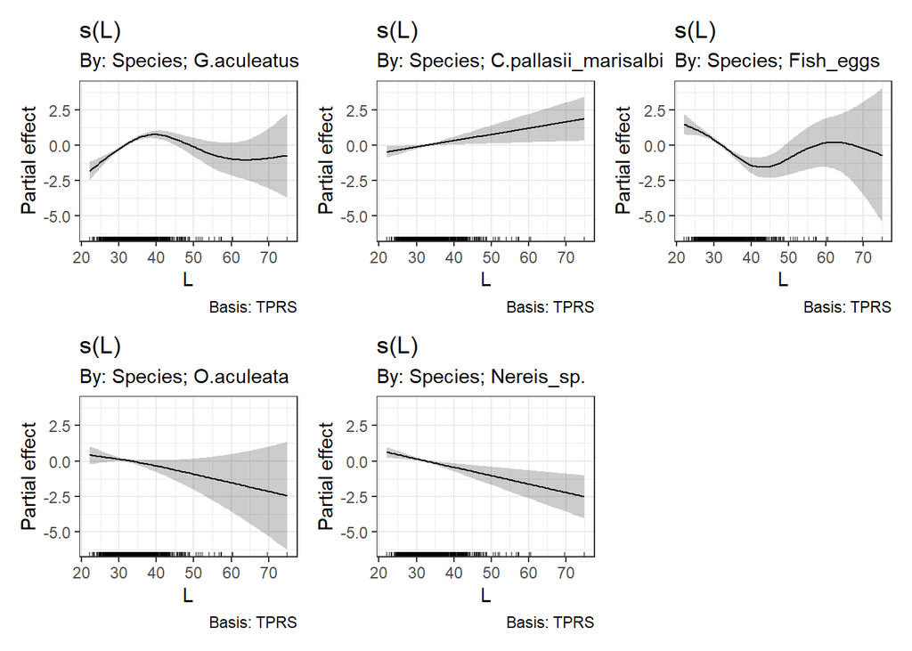

G.aculeatus чаще встречается в питании средних размеров. C.pallasii_marisalbi - чаще у крупных Остальные чаще у мелких.

**Сезонная динамика встречаемости видов**

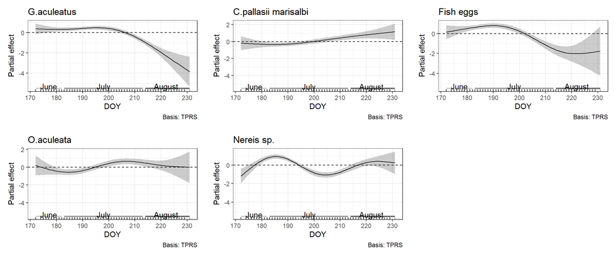

Первую половину лета треска ест колюшку и икру, вторую половину лета - селедку и, возможно, офиур. С нереисами сложнее. Первый пик - это явно период хода нереиса в первой половине лета. Второй пик - может это другой вид нереиса? Надо поискать данные по периодам хода у pelgica и virens.

**Многолетняя динамика встречаемости видов**

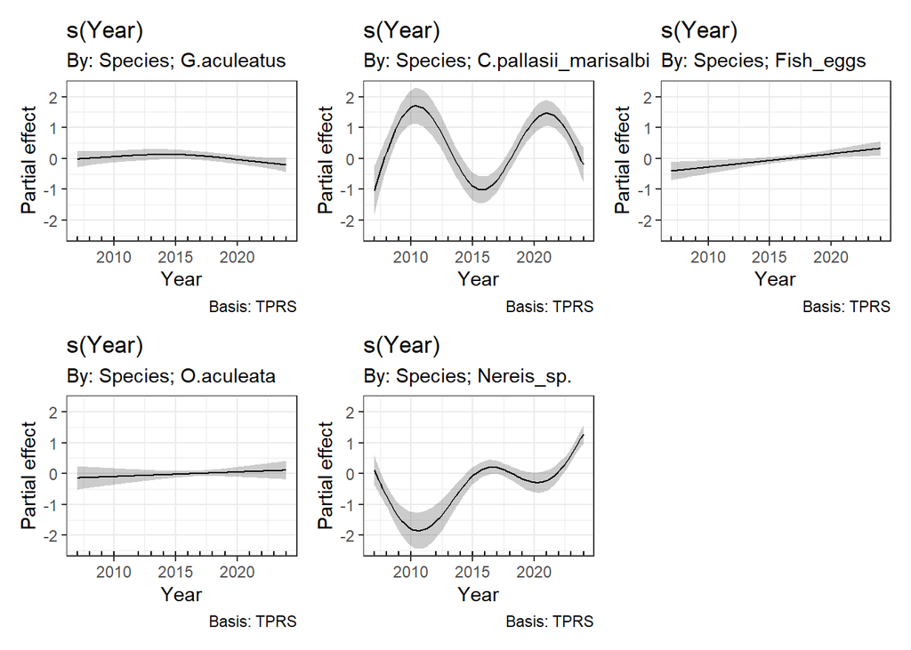

## Динамика доли пищевых объектов

Пока рассматриваем только сезонную динамику. Я усреднил по всем годам долю в пищевом комке для всех частых видов. Те, которые не вошли в число частых, я обозначаю как “Other”. Средние были рассчитаны для десятидневок. Пока закраска цветом, но потом можем заменить на штриховку.

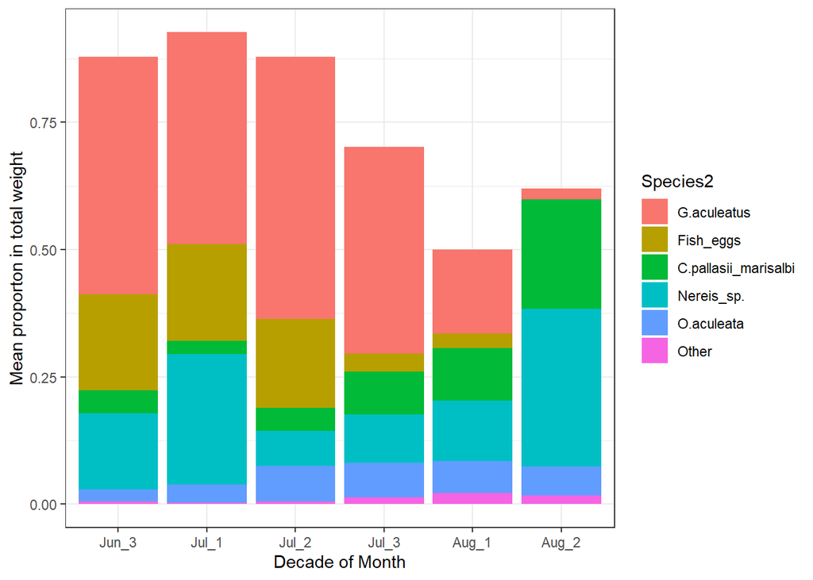

# Новый кусок

## Другой способ вычисления доли

За 100% берется вся сумма весов жертв за декаду. Далее на графике отражаем долю суммы каждого вида в общей сумме за декаду.

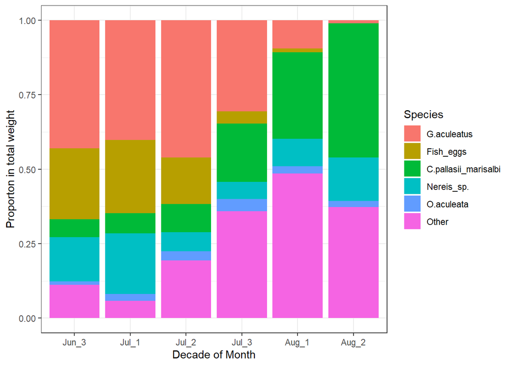

Это другой способ визуализации предыдущего графика. Этот вариант мне кажется лучше. В принципе, можно пустить его в параллель с визуализацией сезонной динамики встречаемости видов (общий ход сезонной динамики встречаемости и доли в пищевом комке похожи)

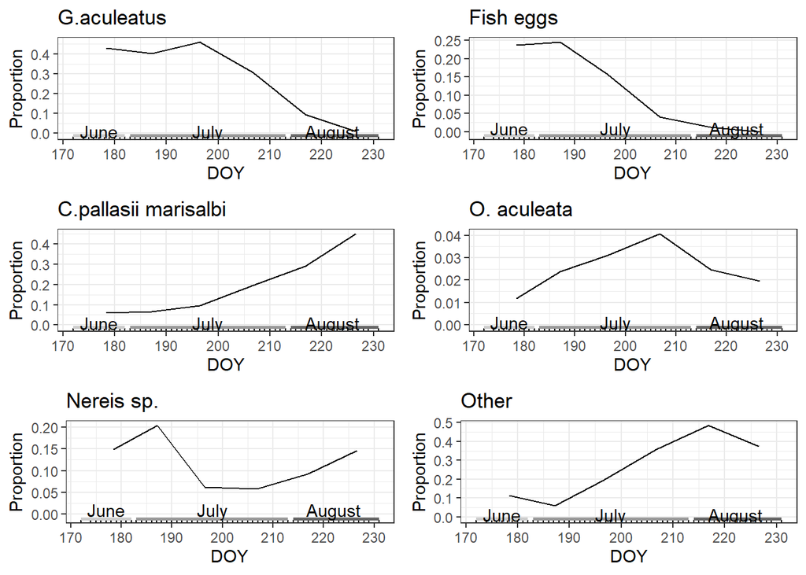

## Многолетняя динамика доли

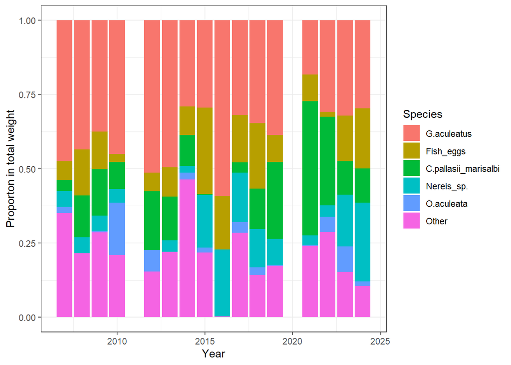

Другой вариант визуализации этого же графика. Здесь точки - исходные доли, синие линии - сглаженная тенденция.

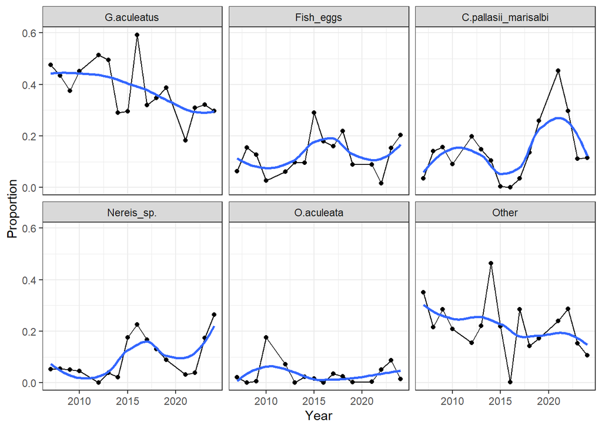